# Mini Project Analysis

Jordan Douglass

10/8/2020

# U.S. Birth Data from 2000-2014

This project will review birth data in the United States from 2000-2014. Variables given from this dataset include: `year`, `month`, `date_of_month`, the full date `date`, `day_of_week`, and `birth` count. These variables assist in creating the following data visualizations.

## Loading the Data

Now that we have loaded our packages, we need to load the data that will be used to create visualizations. The dataset is being read from GitHub directly but can also be viewed in the `/data` sub-folder provided. In addition, a new column, **season** is being added here to allow for another layer of analysis.

```r
birth_data <- read_csv("https://raw.githubusercontent.com/reisanar/datasets/master/us_births_00_14.csv")
#Create a new column identifying the season of births
birth_data <- birth_data %>%
  mutate(
    season = case_when(
      month %in% 10:12 ~ "Fall",
      month %in%  1:3  ~ "Winter",
      month %in%  4:6  ~ "Spring",
      TRUE ~ "Summer"))
summary(birth_data)
```

```
##       year          month        date_of_month        date
##  Min.   :2000   Min.   : 1.000   Min.   : 1.00   Min.   :2000-01-01
##  1st Qu.:2003   1st Qu.: 4.000   1st Qu.: 8.00   1st Qu.:2003-10-01
##  Median :2007   Median : 7.000   Median :16.00   Median :2007-07-02
##  Mean   :2007   Mean   : 6.523   Mean   :15.73   Mean   :2007-07-02
##  3rd Qu.:2011   3rd Qu.:10.000   3rd Qu.:23.00   3rd Qu.:2011-04-01
##  Max.   :2014   Max.   :12.000   Max.   :31.00   Max.   :2014-12-31
##  day_of_week            births         season
##  Length:5479        Min.   : 5728   Length:5479
##  Class :character   1st Qu.: 8740   Class :character
##  Mode  :character   Median :12343   Mode  :character
##                     Mean   :11350
##                     3rd Qu.:13082
##                     Max.   :16081
```

## Calculating Proportions

The following step included finding the proportions of both the occurrences of total births by day of week, year and month.

```r
# find percentage of births by day of week
daily_prop <- birth_data %>%
  group_by(day_of_week) %>%
  summarize(total = sum(births)) %>%
  mutate(prop = round(100* total / sum(total),2))
daily_prop
```

```
## # A tibble: 7 x 3
##   day_of_week    total  prop
##   <chr>          <dbl> <dbl>
## 1 Fri          9850199 15.8
## 2 Mon          9316001 15.0
## 3 Sat          6704495 10.8
## 4 Sun          5886889  9.47
## 5 Thurs       10045436 16.2
## 6 Tues        10274874 16.5
## 7 Wed         10109130 16.3
```

```r
# find percentage of births by year
yearly_prop <- birth_data %>%
  group_by(year) %>%
  summarize(total = sum(births)) %>%
  mutate(prop = round(100* total / sum(total),2))
yearly_prop
```

```
## # A tibble: 15 x 3
##     year   total  prop
##    <dbl>   <dbl> <dbl>
##  1  2000 4149598  6.67
##  2  2001 4110963  6.61
##  3  2002 4099313  6.59
##  4  2003 4163060  6.69
##  5  2004 4186863  6.73
##  6  2005 4211941  6.77
##  7  2006 4335154  6.97
##  8  2007 4380784  7.04
##  9  2008 4310737  6.93
## 10  2009 4190991  6.74
## 11  2010 4055975  6.52
## 12  2011 4006908  6.44
## 13  2012 4000868  6.43
## 14  2013 3973337  6.39
## 15  2014 4010532  6.45
```

```r
# find percentage of births by month
birth_data$date = as.Date(birth_data$date, format="%Y~%m%d")
birth_data$month = format(birth_data$date, format="%B")

monthly_pct <- birth_data %>%
  group_by(month) %>%
  summarize(total = sum(births)) %>%
  mutate(prop = round(100* total / sum(total),2))
monthly_pct
```

```
## # A tibble: 12 x 3
##    month       total  prop
##    <chr>       <dbl> <dbl>
##  1 April     4960750  7.98
##  2 August    5540170  8.91
##  3 December  5194432  8.35
##  4 February  4725693  7.6
##  5 January   5072588  8.16
##  6 July      5450418  8.76
##  7 June      5163360  8.3
##  8 March     5172961  8.32
##  9 May       5195445  8.35
## 10 November  5008750  8.05
## 11 October   5302865  8.53
## 12 September 5399592  8.68
```

```r
monthly_avg <- birth_data %>%
  group_by(month) %>%
  summarize(avg = mean(births))
monthly_avg
```

```
## # A tibble: 12 x 2
##    month        avg
##    <chr>      <dbl>
##  1 April     11024.
##  2 August    11914.
##  3 December  11171.
##  4 February  11146.
##  5 January   10909.
##  6 July      11721.
##  7 June      11474.
##  8 March     11125.
##  9 May       11173
## 10 November  11131.
## 11 October   11404.
## 12 September 11999.
```

## First Visualization!

We’ve **finally** made it to our first data visualization! This plot is Births Over Time - there is quite a lot of data found from the `date` variable. Because of this, our visualization looks overwhelming and a bit confusing… Truly, I’m not sure what I am even looking at. Our next steps should be breaking it down to see a bit more closely.

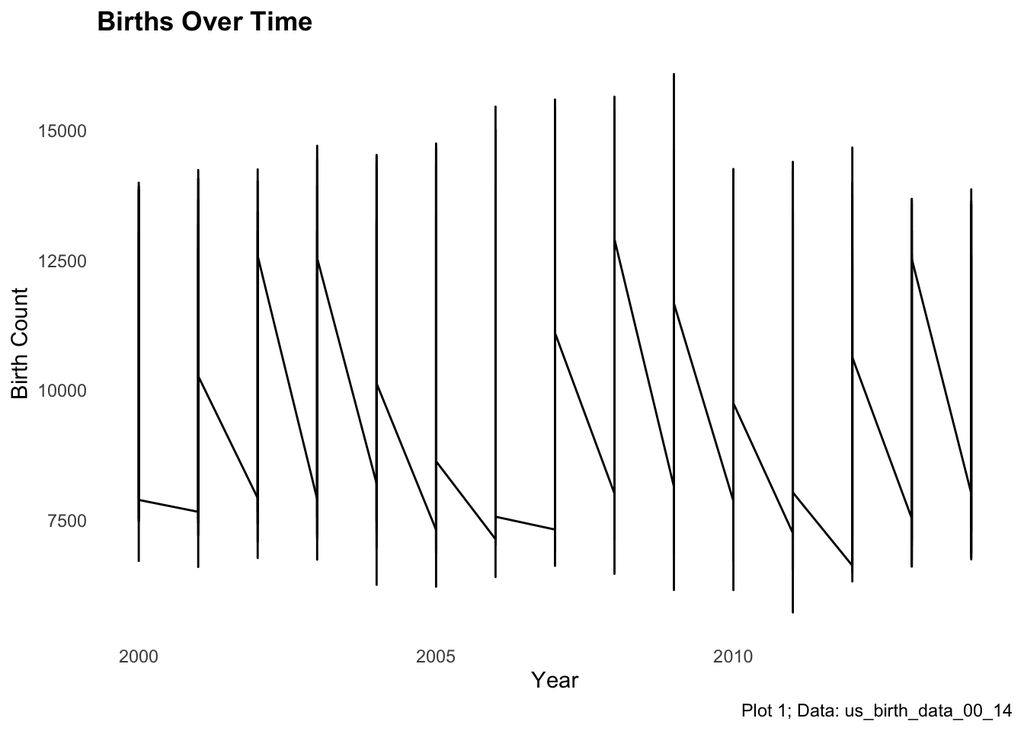

```r
tme <- ggplot(birth_data, aes(x = year, y = births)) +
  geom_line() +
  labs(title = "Births Over Time",
       x = "Year",
       y = "Birth Count",
       caption = "Plot 1; Data: us_birth_data_00_14") +
  theme_minimal() +
  theme( panel.grid.major = element_blank(), panel.grid.minor = element_blank(), plot.title = element_text(face="bold"))
tme
```

## Second Visualization

This visualization shows the count of births by day of the week. From this we can see that fewer births occurred on the weekend (Saturday and Sunday) than weekdays - Friday, on the other hand looks to be pretty popular.

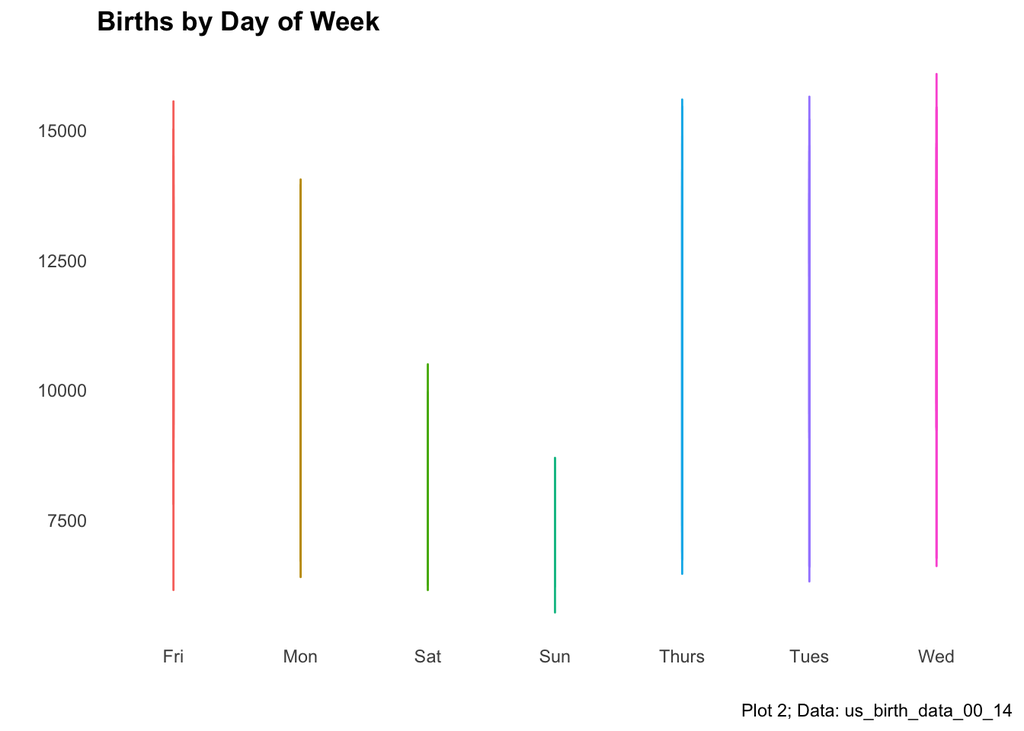

```r
ggplot(birth_data, aes(day_of_week, births)) +
  geom_line(aes(colour = day_of_week)) +
  labs(title = "Births by Day of Week",
       x = "",
       y = "",
       caption = "Plot 2; Data: us_birth_data_00_14") +
      theme_minimal() +
       theme(panel.grid.major = element_blank(), panel.grid.minor = element_blank(), legend.title = element_blank(), legend.position = "none", plot.title = element_text(face="bold"))
```

## Third Visualization

Unfortunately, the Treemap created is not as extravagant as many others I’ve seen - it reminds me of a pie-chart in its level of use, the divided features are not easy to distinguish as all of the proportions are relatively equal or varying by 1%.

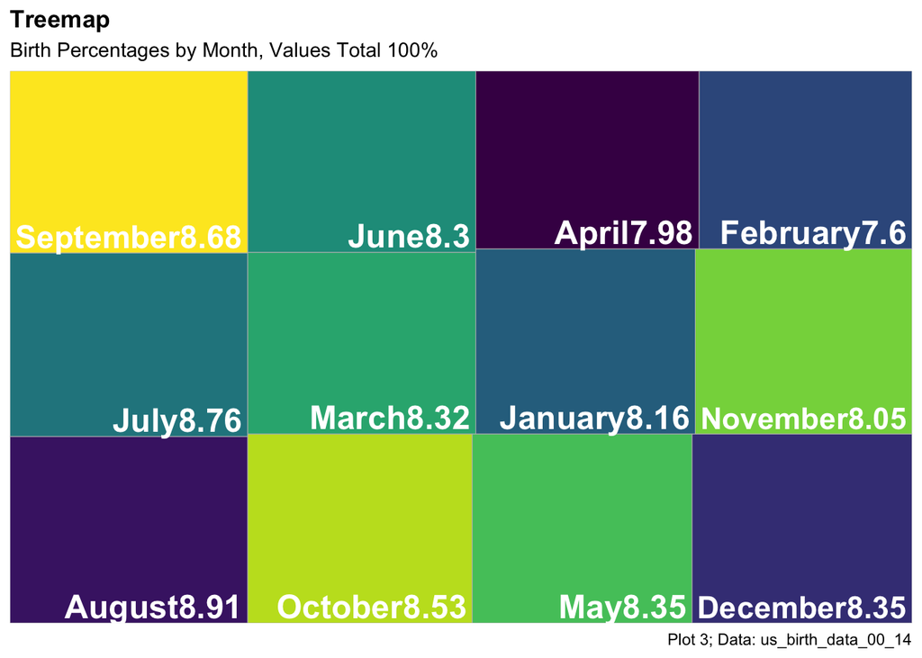

```r
tm1 <- ggplot(monthly_pct, aes(area = total, fill = month, label = paste(month, prop, sep = ""))) +
  geom_treemap(show.legend = FALSE) +
  geom_treemap_text(fontface = "bold", colour="white", place="bottomright", grow = FALSE) +
  scale_fill_viridis_d() +
  labs(title = "Treemap",
       subtitle = "Birth Percentages by Month, Values Total 100%",
       caption = "Plot 3; Data: us_birth_data_00_14") +
  theme( plot.title = element_text(face="bold"))
tm1
```

## Fourth Visualization

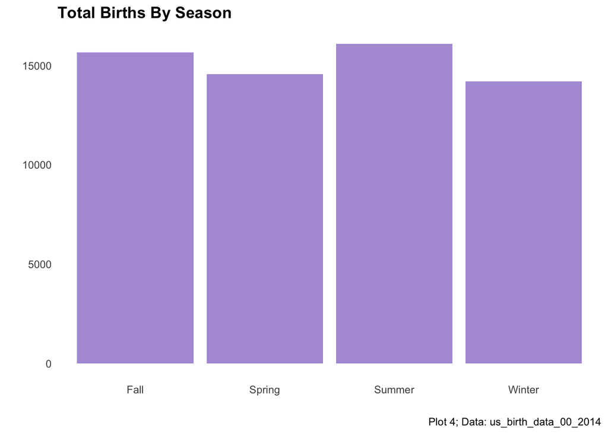

```r
ggplot(birth_data, aes(x=season, y=births)) +
  geom_bar(stat="identity", position = position_dodge(), fill="#b19cd9") +
  labs(title = "Total Births By Season",
       x = "",
       y = "",
       caption = "Plot 4; Data: us_birth_data_00_2014") +
   theme_minimal() +
  theme(panel.grid.major = element_blank(), panel.grid.minor = element_blank(), legend.title = element_blank(), plot.title = element_text(face="bold"))
```

## Fifth Visualization

*You’ve made it to the final visualization!* The fifth and final visualization shows birth counts by years. As before, we have also used the `season` variable here.

By adding seasons, we can see how births fluctuated by time of year over the series. Summer of 2009 shows the highest count of births.

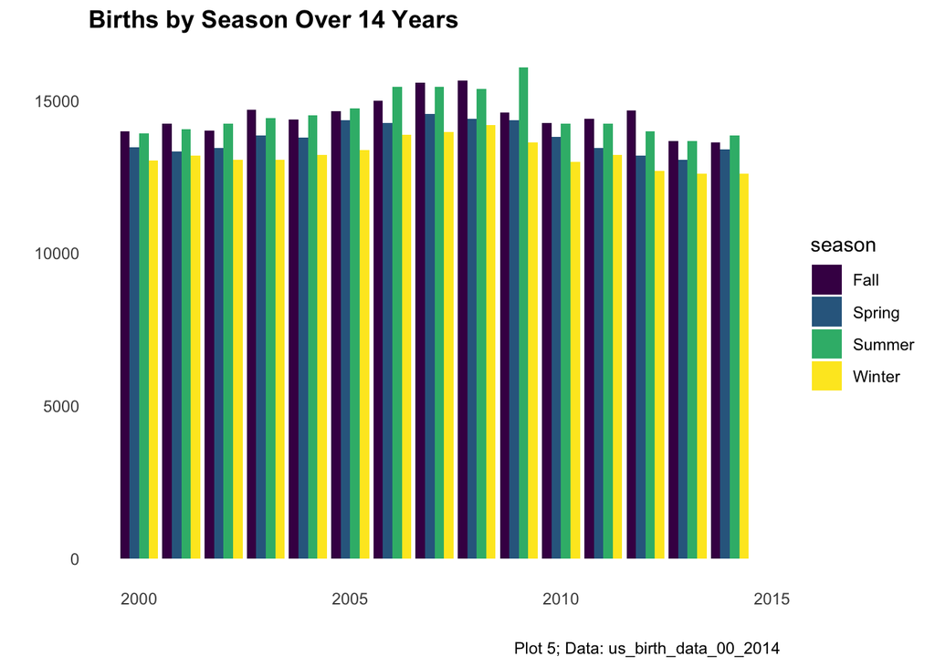

```r
ggplot(birth_data, aes(year, births, fill=season)) +
  geom_bar(stat = "identity", position = position_dodge()) +
  scale_fill_viridis_d() +
  labs(title = "Births by Season Over 14 Years",
       x = "",
       y = "",
       caption = "Plot 5; Data: us_birth_data_00_2014") +
  theme_minimal() +
  theme(panel.grid.major = element_blank(), panel.grid.minor = element_blank(), plot.title = element_text(face="bold"))
```

# Report

After opening the .csv file for the `us_birth_data_00_14`, I assumed that I had a pretty good idea of wrangling and creating visualizations into R. Some things did not go according to plan.

It’s not often that I get to work with `date` data and I wanted to take advantage of the `lubridate` library to do just that. Initially, my data was downloaded and imported directly from my machine - lubridate did not take that very well. After loaded from GitHub, using that functionality was much easier.

Once the date format was in order, I wanted to create the season variable just to offer a new column (as this file only had a few) that could provide more visualizations.

### Original Chart Plans

- Visualize by Season
  - Completed (Plot 4)
- Births by day of the week
  - Completed (Plot 2)
- Visualize by month
  - Completed (Plot 3)
- Visualize by year
  - Completed (Plot 1, Plot 5)
- Measure by % by month or year
  - Completed (Plot 3)
- Use color proportions
- Calculation of births by season

### Storytelling with the Data

Interesting stories to come from this data was from the Days of the Week births and the Season Births.

It was very interesting to see Weekend births varied so drastically compared to Weekdays. Some things to think about: * Do weekdays induce labor due to stress? * Are women more likely to be induced for labor by physicians on weekdays? * Are men watching College and NFL football on the weekends directly correlated to low weekend births?

Secondly, visualizing the season variable brought some interesting ways to tell a story. Although the data is not as dramatically varied as births by day of week, more births occurred in the Summer than any other season and fewer occurred in the Winter. In addition, Summer babies in 2009 were the highest data point overall.

Makes you wonder what was going down in the Fall of 2008… Other than the housing market.

And finally, Plot 1 shows that around 2006, there was an influx of births until 2009 compared to other years, which could tell an interesting story with more variables available.

### Principles of Data Visualization and Design

After several iterations, the visualizations provided looked to be the most promising options. By getting rid of most grid lines, the visualizations look more appealing and by removing x- and y-axis labels the visualizations look much cleaner.

#### Aesthetics

The majority of plots created used the aes() function for aesthetics but I could not find good use for mapping() that adding value to the plots (which was disappointing). The Viridis palette and default palette were used in the visualizations.

#### Proportions

The group_by() and mutate() functions were used to create proportions, averages and assign seasons to months.

#### Geometries

Different graph types were created including bar graphs, line graphs and a treemap to better visualize the data.

#### Future Mini Projects

In the following projects, I hope to include more scatter plots and histograms that map aesthetics better than what I was previously creating. I also hope to have the opportunity to use data to create Maps (Chapter 7). Interesting stories could be told on birth data if States were included.